### Visualization of SMDX data The case of Eurostat’s sudtainable development goals

#### Athanassios Stavrakoudis & Małgorzata Burchard -Dziubińska

University of Ioannina, Uniwersytet Łódzki

astavrak@uoi.gr, malgorzata.burchard@uni.lodz.pl

Ioannina, 30 May 2019

# Sustainable Development Indicators

https://ec.europa.eu/eurostat/web/sdi/indicators

[figure not shown]

# SMDX data

SDMX, which stands for Statistical Data and Metadata eXchange is an international initiative that aims at standardising and modernising (“industrialising”) the mechanisms and processes for the exchange of statistical data and metadata among international organisations and their member countries

**Eurostat**, **OECD**, **UN**, **World Bank**, **IMF** and many others use SDMX in order to transit their datasets.

Using R one can handle these datasets either with the **rsdmx** library or with specific APIs, like the **eurostat** library: https://ropengov.github.io/eurostat/

# Data download

Every dataset from Eurostat can be defined by a unique name. We just need to provide this name to the API, for example:

```r
library(tidyverse)
library(eurostat)
get_eurostat("tin00028")
```

```
## Table tin00028 cached at /tmp/Rtmp22SOvP/eurostat/tin00028_date_code_TF.rds
```

```
## # A tibble: 1,712 x 6
##    ind_type  unit   indic_is geo   time       values
##    <fct>     <fct>  <fct>    <fct> <date>      <dbl>
##  1 IND_TOTAL PC_IND I_ILT12  AT    2007-01-01     69
##  2 IND_TOTAL PC_IND I_ILT12  BE    2007-01-01     69
##  3 IND_TOTAL PC_IND I_ILT12  BG    2007-01-01     34
##  4 IND_TOTAL PC_IND I_ILT12  CY    2007-01-01     41
##  5 IND_TOTAL PC_IND I_ILT12  CZ    2007-01-01     52
##  6 IND_TOTAL PC_IND I_ILT12  DE    2007-01-01     75
##  7 IND_TOTAL PC_IND I_ILT12  DK    2007-01-01     85
##  8 IND_TOTAL PC_IND I_ILT12  EA    2007-01-01     61
##  9 IND_TOTAL PC_IND I_ILT12  EE    2007-01-01     66
## 10 IND_TOTAL PC_IND I_ILT12  EL    2007-01-01     36
## # … with 1,702 more rows
```

# Eurostat distributed datasets

### Eurostat has to collect, process and distribute:

- values for something (for example internet usage)
- for several countries or regions of countries
- for several times (yearly, quertely or monthly data)

### With a common and stable format

- as time passes by
- as new countries enter
- some countries might go

# Eurostat web interface

Eurostat: Internet use by individuals

https://ec.europa.eu/eurostat/data/database?node_code=tin00028

[figure not shown]

# Eurostat web interface (2)

Eurostat: Internet usage by individuals

https://ec.europa.eu/eurostat/tgm/table.do?tab=table&plugin=1&language=en&pcode=tin00028

[figure not shown]

# Eurostat data download options

https://ec.europa.eu/eurostat/tgm/download.do?tab=table&plugin=1&language=en&pcode=tin00028

[figure not shown]

# Eurostat Excel files

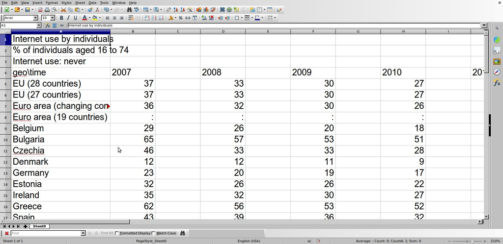

#### Disadvantages

- Dirty data
- Need some data cleaning before processing
- Mixes data with descriptions
- Separate coluns for each year!

but:

What You See is What You Get

# SMDX data storage and use

Of course, we do not store datasets in this format.

So, there is no reason to use them in this format.

Forget Excel files and use directly SDMX tables. It’s Easy!

- Locations (countries, regions and etc) are stored in one single column: **geo**
- Time (years, quarters, months, etc) are stored in one sigle column: **time** is ISO format (YYYY-MM-DD)
- Values (of anything) are stored in one single column: **values**
- Other characteristics are stored in separate columns
- The triplet **(geo, time, values)** is common everywhere

That’s easy!

# INSERT, DELETE, UPDATE data

- If we have to add a new value, we have to **INSERT** a row
- If we have to delete a value, we **DELETE** a row
- If we have to update a value, we **UPDATE** a row

This **rowwise** procedure, very similar to relational databases and **SQL** is essential.

We do not perform these actions to the actual data sets, we ARE NOT the Eurostat data administrators.

But as we DO data management and analysis we have to do it sometimes.

So, in every dataset:

- Every column is a variable
- Every row is an observation

# Employment in high- and medium-high technology manufacturing and knowledge-intensive services

### This is the SDI 9.2

#### Let’s compare Greece with Germany and UK and guess why young Greek scientists emigrate

[figure not shown]

```r
sdg_09_20 %>%
  filter(nace_r2 == 'C_HTC_MH') %>%
  filter(geo %in% c('EL', 'DE', 'UK')) %>%
  mutate(lbl = if_else(time == max(time), as.character(Country), NA_character_)) %>%
  ggplot(aes(x = time, y = values, colour = Country)) +
  geom_line(size = 1) +
  scale_x_continuous(breaks = seq(2006, 2018, by = 2)) +
  scale_y_continuous(limits = c(0, 12), breaks = seq(0, 12, by = 2)) +
  geom_label_repel(aes(label = label), nudge_x = 1, nudge_y = 1, na.rm = TRUE) +
  theme_economist() +
  theme(text = element_text(size = 16)) +
  theme(legend.position = "none")
```

# A map

### Employment in high- and medium-high technology manufacturing and knowledge-intensive services

```r
SHP0 <- read_rds("../data/SHP0.rds")

DF <- sdg_09_20 %>%
  inner_join(SHP0, by = "geo") %>%
  st_as_sf %>%
  filter(nace_r2 == 'C_HTC_MH') %>%
  filter(time == 2018)

myPal  <- colorNumeric(palette = "Blues",  domain = c(0, DF$values))
LABELS <- paste0("<h3>", DF$Country, " : ", DF$values, "%</h3>") %>%
  lapply(HTML)

DF %>%
  leaflet() %>%
  setView(lng = 12.25, lat = 51.34, zoom = 4) %>%
  addPolygons(weight = 1, color = "black",
              fillColor = ~myPal(values), fillOpacity = 0.9, label = LABELS) %>%
  addLegend("topright", pal = myPal, values = ~values, title = "% of employment") %>%
  addControl(html = "<small>(C) EuroGeographics for the administrative boundaries</small>",
             position = "bottomleft")
```

[interactive chart not shown]